# Exercise 4.1

Lucia Camenisch

23 octobre 2022

Before answering any questions, let us set up our framework and prepare the data. In this code chunk, we:

1. Load the necessary R packages,
2. Import the data from the CSV file,
3. Take a look at the first lines of our data,
4. Check for missing values

```r
library(data.table) # data tables, fread
library(ggplot2)    # plotting
library(knitr)      # r markdown
library(kableExtra) # kable parameters
library(dplyr)      # summarise()
library(tidyr)      # pivot_longer()
library(plot.matrix)# plotting matrix heatmaps

Cereals <- fread("Cereals.csv") # importing the data

# displaying the first five rows of data
kable_styling(kable(head(Cereals, 5), col.names = c("name", "mfr", "type", "cal", "prot", "fat", "sodium", "fiber", "carbo", "sugars", "potass", "vit", "shelf", "weight", "cups", "rating")), full_width = TRUE)
```

| name | mfr | type | cal | prot | fat | sodium | fiber | carbo | sugars | potass | vit | shelf | weight | cups | rating |
| --- | --- | --- | --- | --- | --- | --- | --- | --- | --- | --- | --- | --- | --- | --- | --- |
| 100%_Bran | N | C | 70 | 4 | 1 | 130 | 10 | 5 | 6 | 280 | 25 | 3 | 1 | 0.33 | 68.40297 |
| 100%_Natural_Bran | Q | C | 120 | 3 | 5 | 15 | 2 | 8 | 8 | 135 | 0 | 3 | 1 | 1.00 | 33.98368 |
| All-Bran | K | C | 70 | 4 | 1 | 260 | 9 | 7 | 5 | 320 | 25 | 3 | 1 | 0.33 | 59.42551 |
| All-Bran_with_Extra_Fiber | K | C | 50 | 4 | 0 | 140 | 14 | 8 | 0 | 330 | 25 | 3 | 1 | 0.50 | 93.70491 |
| Almond_Delight | R | C | 110 | 2 | 2 | 200 | 1 | 14 | 8 | NA | 25 | 3 | 1 | 0.75 | 34.38484 |

```r
colSums(is.na(Cereals)) # checking if some variables contain missing values
```

```
##     name      mfr     type calories  protein      fat   sodium    fiber
##        0        0        0        0        0        0        0        0
##    carbo   sugars   potass vitamins    shelf   weight     cups   rating
##        1        1        2        0        0        0        0        0
```

```r
# displaying the rows and columns containing missing values
kable_styling(kable(Cereals[rowSums(is.na(Cereals)) > 0,list(name,carbo, sugars, potass)]), full_width = FALSE)
```

| name | carbo | sugars | potass |
| --- | --- | --- | --- |
| Almond_Delight | 14 | 8 | NA |
| Cream_of_Wheat_(Quick) | 21 | 0 | NA |
| Quaker_Oatmeal | NA | NA | 110 |

We spot one missing value in `carbo` and `sugars`, as well as two missing values in `potass`. The involved cereal brands are Almond Delight, Cream of Wheat (Quick) and Quaker Oatmeal.

# 1 Which variables are quantitative/numerical? Which are ordinal? Which are nominal?

- `name`, `mfr` and `type` are nominal variables,
- `shelf` is an ordinal variable,
- all other variables are quantitative.

# 2 Compute the mean, median, min, max, and standard deviation for each of the quantitative variables.

```r
# creating a table with only quantitative variables
CerealsQuantitative <- Cereals [, list(calories, protein, fat, sodium, fiber, carbo, sugars, potass, vitamins, weight, cups, rating)]


# creating CerealsSummary table to store our results
CerealsSummary <- data.table(Variables = c("calories", "protein", "fat", "sodium", "fiber", "carbo", "sugars", "potass", "vitamins", "weight", "cups", "rating"))

# creating these temporary data tables for each of the five functions. We use sapply as suggested.
Mean = as.data.table(sapply(CerealsQuantitative, mean, na.rm = TRUE))
Median = as.data.table(sapply(CerealsQuantitative, median, na.rm = TRUE))
Min = as.data.table(sapply(CerealsQuantitative, min, na.rm = TRUE))
Max = as.data.table(sapply(CerealsQuantitative, max, na.rm = TRUE))
SD = as.data.table(sapply(CerealsQuantitative, sd, na.rm = TRUE))

# pasting each column of our five tables into CerealsSummary
CerealsSummary <- CerealsSummary[, Mean := Mean$V1]
CerealsSummary <- CerealsSummary[, Median := Median$V1]
CerealsSummary <- CerealsSummary[, Min := Min$V1]
CerealsSummary <- CerealsSummary[, Max := Max$V1]
CerealsSummary <- CerealsSummary[, SD := SD$V1]

# displaying the result with kable
kable_styling(kable(CerealsSummary), full_width = FALSE)
```

| Variables | Mean | Median | Min | Max | SD |
| --- | --- | --- | --- | --- | --- |
| calories | 106.883117 | 110.00000 | 50.00000 | 160.00000 | 19.4841191 |
| protein | 2.545454 | 3.00000 | 1.00000 | 6.00000 | 1.0947897 |
| fat | 1.012987 | 1.00000 | 0.00000 | 5.00000 | 1.0064726 |
| sodium | 159.675325 | 180.00000 | 0.00000 | 320.00000 | 83.8322952 |
| fiber | 2.151948 | 2.00000 | 0.00000 | 14.00000 | 2.3833640 |
| carbo | 14.802632 | 14.50000 | 5.00000 | 23.00000 | 3.9073256 |
| sugars | 7.026316 | 7.00000 | 0.00000 | 15.00000 | 4.3786564 |
| potass | 98.666667 | 90.00000 | 15.00000 | 330.00000 | 70.4106360 |
| vitamins | 28.246753 | 25.00000 | 0.00000 | 100.00000 | 22.3425225 |
| weight | 1.029610 | 1.00000 | 0.50000 | 1.50000 | 0.1504768 |
| cups | 0.821039 | 0.75000 | 0.25000 | 1.50000 | 0.2327161 |
| rating | 42.665705 | 40.40021 | 18.04285 | 93.70491 | 14.0472887 |

```r
# removing the five temporary data tables from our environment
rm(Mean)
rm(Median)
rm(Min)
rm(Max)
rm(SD)
```

# 3 Use R to plot a histogram for each of the quantitative variables.

We plot the 12 histograms:

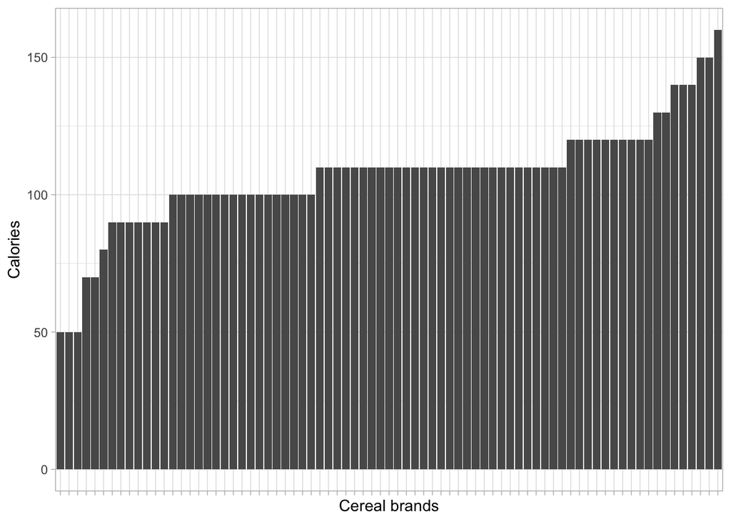

```r
CerealsQuantitative <- CerealsQuantitative[, name := Cereals$name] # we reintroduce the name column

# we plot the 12 histograms for each quantitative variable.
ggplot(CerealsQuantitative, aes(x = reorder(name, calories), y = calories)) +
  geom_bar(stat = "identity") + theme_light() + labs(x = "Cereal brands", y = "Calories") +
  theme(axis.text.x = element_blank())
```

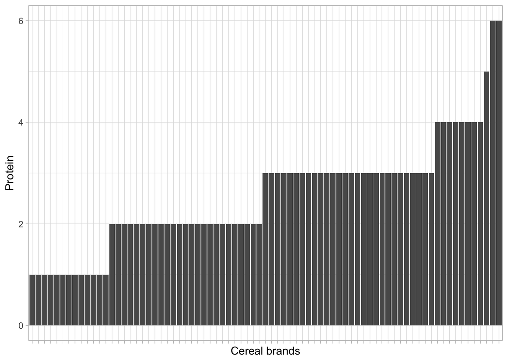

```r
ggplot(CerealsQuantitative, aes(x = reorder(name, protein), y = protein)) +
  geom_bar(stat = "identity") + theme_light() + labs(x = "Cereal brands", y = "Protein") +
  theme(axis.text.x = element_blank())
```

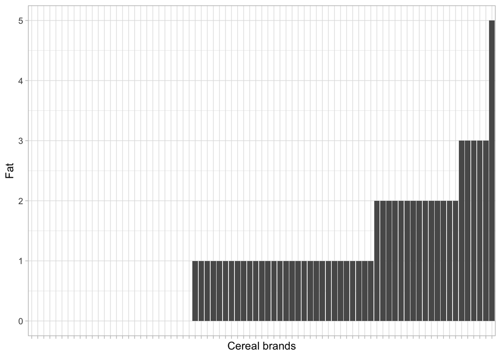

```r
ggplot(CerealsQuantitative, aes(x = reorder(name, fat), y = fat)) +
  geom_bar(stat = "identity") + theme_light() + labs(x = "Cereal brands", y = "Fat") +
  theme(axis.text.x = element_blank())
```

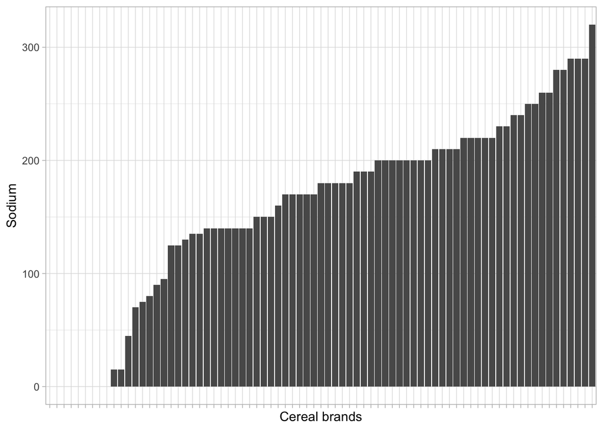

```r
ggplot(CerealsQuantitative, aes(x = reorder(name, sodium), y = sodium)) +
  geom_bar(stat = "identity") + theme_light() + labs(x = "Cereal brands", y = "Sodium") +
  theme(axis.text.x = element_blank())
```

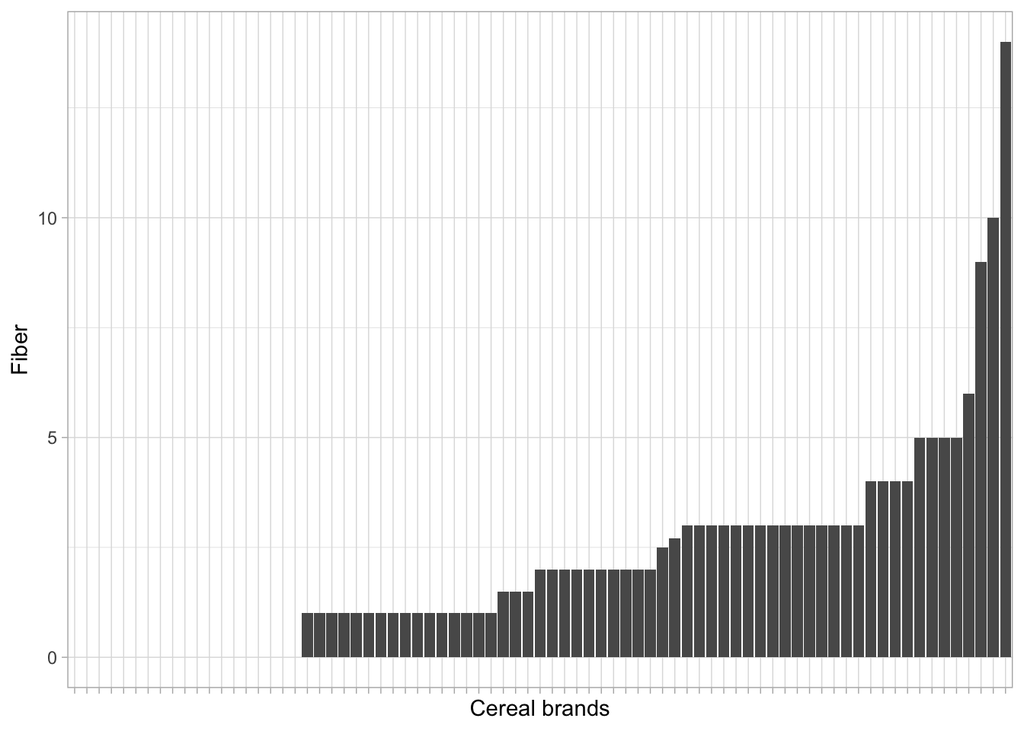

```r
ggplot(CerealsQuantitative, aes(x = reorder(name, fiber), y = fiber)) +
  geom_bar(stat = "identity") + theme_light() + labs(x = "Cereal brands", y = "Fiber") +
  theme(axis.text.x = element_blank())
```

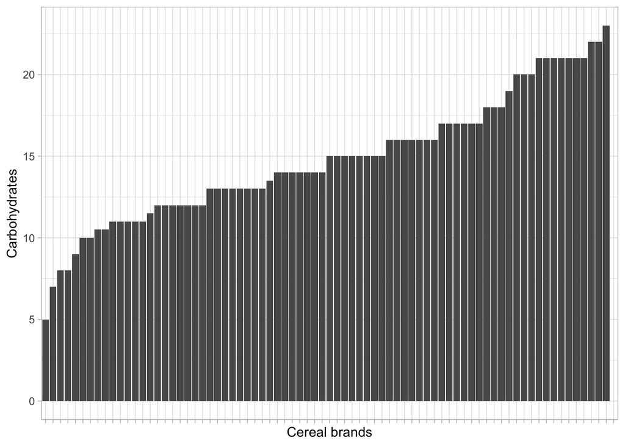

```r
ggplot(CerealsQuantitative, aes(x = reorder(name, carbo), y = carbo)) +
  geom_bar(stat = "identity") + theme_light() + labs(x = "Cereal brands", y = "Carbohydrates") +
  theme(axis.text.x = element_blank())
```

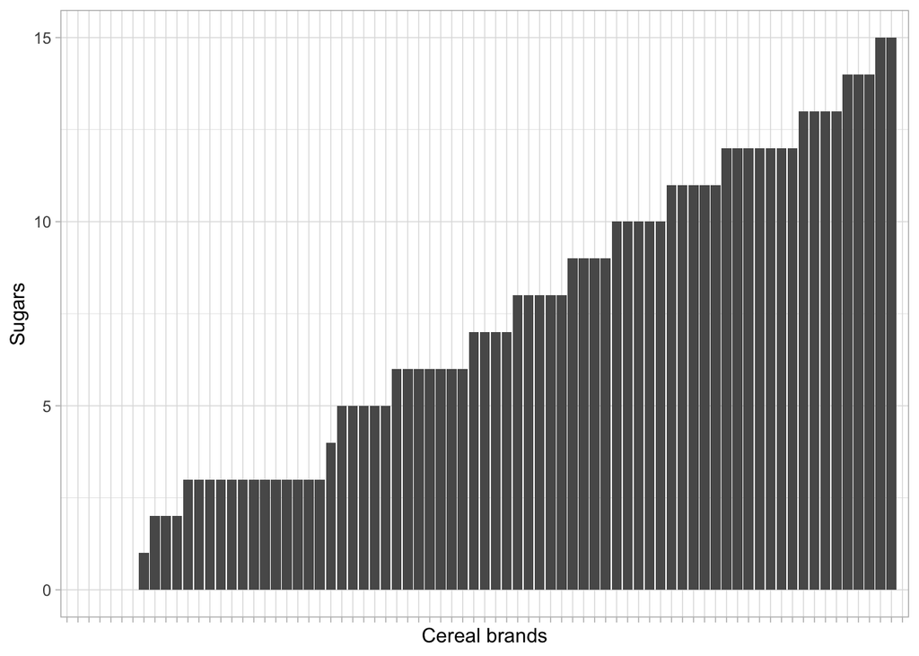

```r
ggplot(CerealsQuantitative, aes(x = reorder(name, sugars), y = sugars)) +
  geom_bar(stat = "identity") + theme_light() + labs(x = "Cereal brands", y = "Sugars") +
  theme(axis.text.x = element_blank())
```

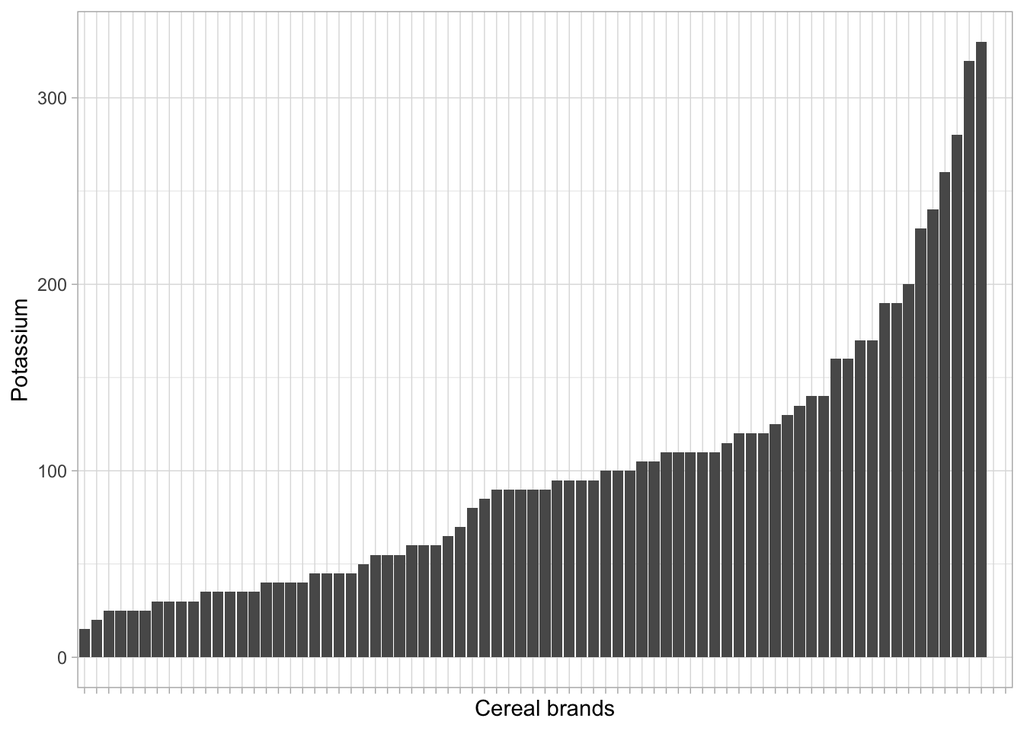

```r
ggplot(CerealsQuantitative, aes(x = reorder(name, potass), y = potass)) +
  geom_bar(stat = "identity") + theme_light() + labs(x = "Cereal brands", y = "Potassium") +
  theme(axis.text.x = element_blank())
```

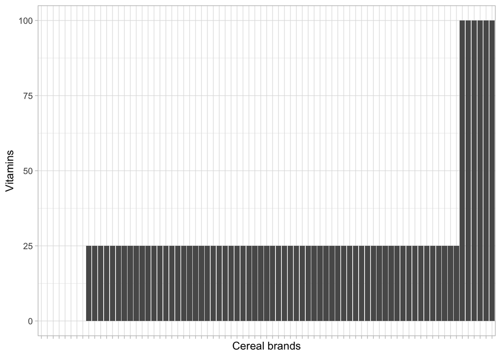

```r
ggplot(CerealsQuantitative, aes(x = reorder(name, vitamins), y = vitamins)) +
  geom_bar(stat = "identity") + theme_light() + labs(x = "Cereal brands", y = "Vitamins") +
  theme(axis.text.x = element_blank())
```

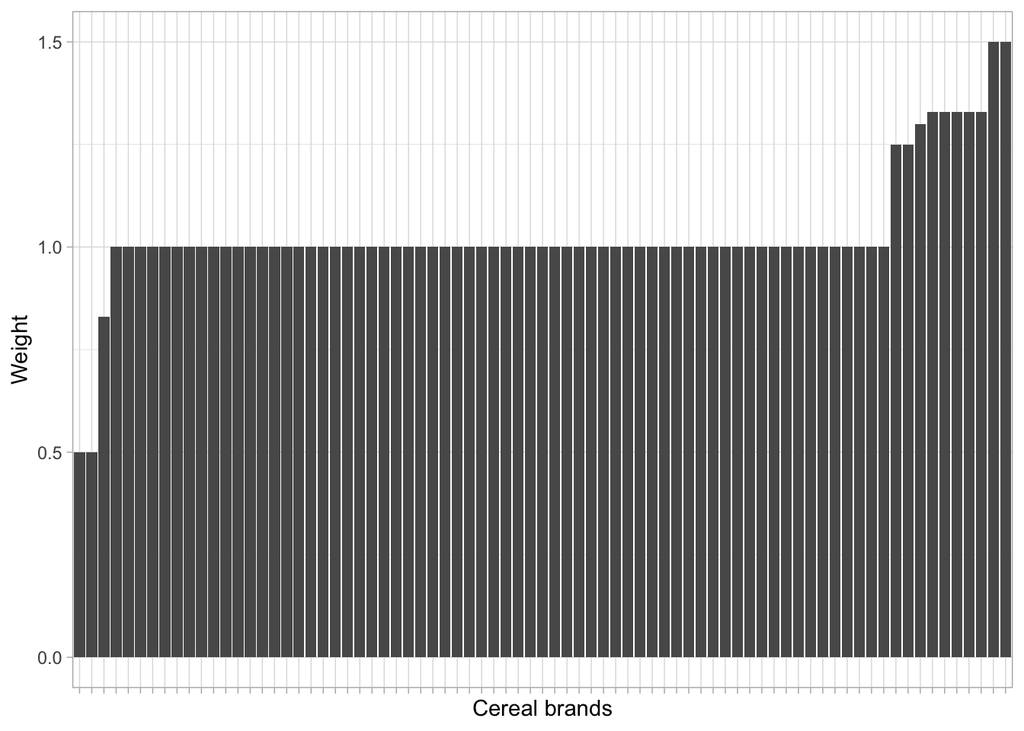

```r
ggplot(CerealsQuantitative, aes(x = reorder(name, weight), y = weight)) +
  geom_bar(stat = "identity") + theme_light() + labs(x = "Cereal brands", y = "Weight") +
  theme(axis.text.x = element_blank())
```

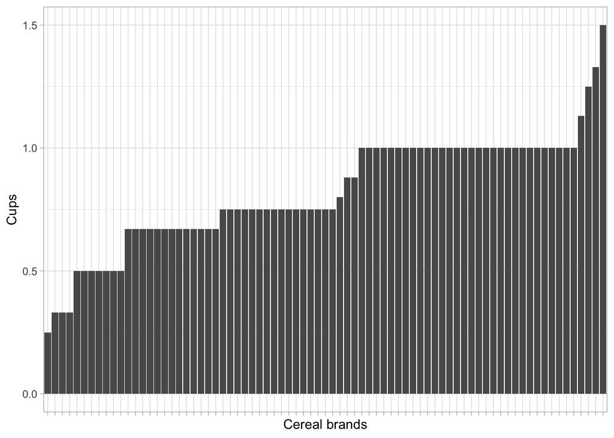

```r
ggplot(CerealsQuantitative, aes(x = reorder(name, cups), y = cups)) +
  geom_bar(stat = "identity") + theme_light() + labs(x = "Cereal brands", y = "Cups") +
  theme(axis.text.x = element_blank())
```

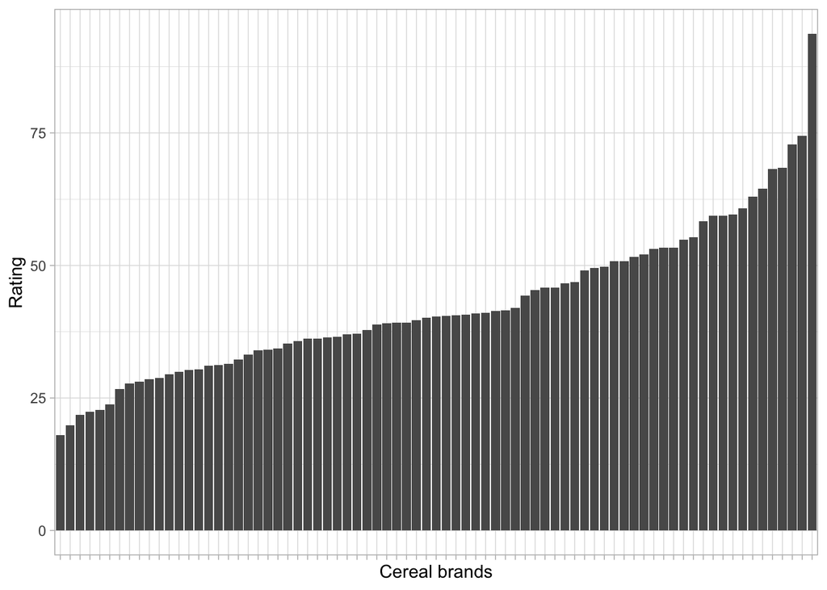

```r
ggplot(CerealsQuantitative, aes(x = reorder(name, rating), y = rating)) +
  geom_bar(stat = "identity") + theme_light() + labs(x = "Cereal brands", y = "Rating") +
  theme(axis.text.x = element_blank())
```

## 3.1 Which variables have the largest variability?

Based on standard deviation, Sodium, Potassium, Vitamins, Calories and Ratings have the largest variabilities.

## 3.2 Which variables seem skewed?

Looking at the histograms, Fat, Fiber and Vitamins seem to be the most skewed variables.

## 3.3 Are there any values that seem extreme?

The three skewed variables, Fat, Fiber and Vitamins, all have some extreme values. Moreover, Protein, Cups and Ratings also have a few extreme values.

# 4 Use R to plot a side-by-side boxplot comparing the calories in hot vs. cold cereals. What does this plot show us?

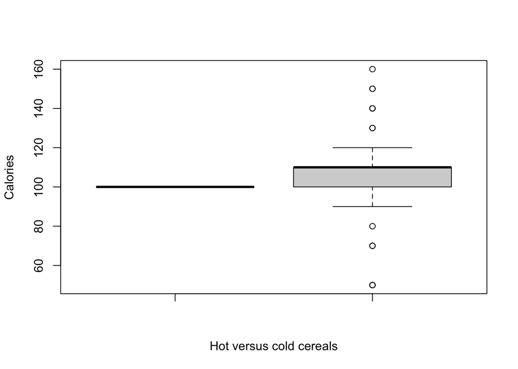

```r
HotCals <- Cereals[type %in% "H", calories] # selecting only calories of hot cereals
ColdCals <- Cereals[type %in% "C", calories] # selecting only calories of cold cereals

#plotting the two boxplots
boxplot(HotCals, ColdCals, xlab = c("Hot versus cold cereals"), ylab = "Calories")
```

Hot cereals all have 100 calories, whereas the calories of cold cereals vary much more. We can note that 100 is close to cold cereals mean and median values (respectively 107 and 110 calories).

However, this comparison might not be very representative, as there are only three cereal brands with hot cereals out of our 77 brands.

# 5 Use R to plot a side-by-side boxplot of consumer rating as a function of the shelf height. If we were to predict consumer rating from shelf height, does it appear that we need to keep all three categories of shelf height?

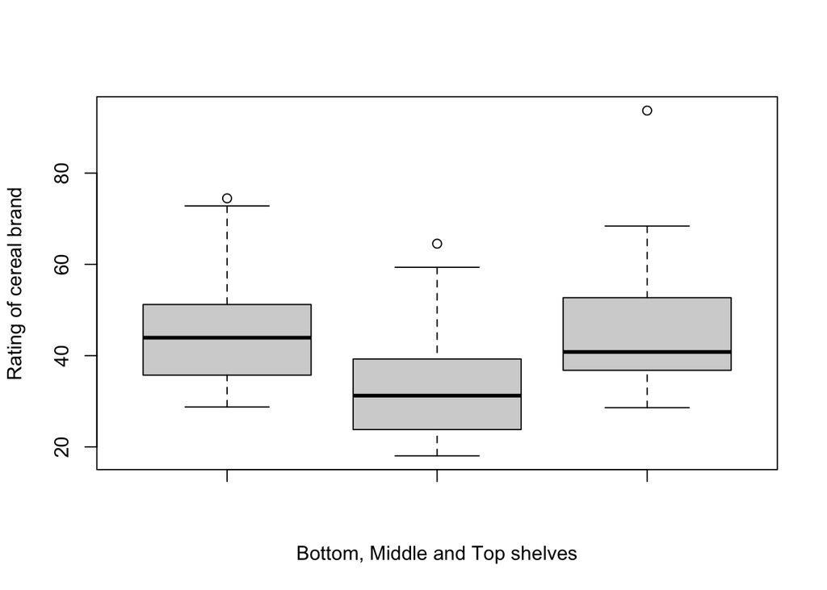

```r
RatingTopShelf <- Cereals[shelf %in% 3, rating] # selecting only ratings from top shelf
RatingMidShelf <- Cereals[shelf %in% 2, rating] # selecting only ratings from middle shelf
RatingBotShelf <- Cereals[shelf %in% 1, rating] # selecting only ratings from bottom shelf

# making three boxplots
boxplot(RatingBotShelf, RatingMidShelf, RatingTopShelf, xlab = "Bottom, Middle and Top shelves", ylab = "Rating of cereal brand")
```

Clearly, the middle shelf has lower rating than the bottom and top shelves. We could consider getting rid of this shelf. The other two shelves have roughly the same ratings, with a higher median value for the bottom one.

# 6 Compute the correlation table for the quantitative variables. In addition, generate a matrix plot for these variables.

```r
CerealsQuantitative <- Cereals[, list(calories, protein, fat, sodium, fiber, carbo, sugars, potass, vitamins, weight, cups, rating)] # taking out name again from quantitative table
QuantCor = cor(x = CerealsQuantitative, use = "complete.obs") # computing correlation matrix and omitting NA values from calculations (with complete.obs)

# displaying the resulting matrix as a table
kable_styling(kable(round(QuantCor,3)), full_width = TRUE)
```

|  | calories | protein | fat | sodium | fiber | carbo | sugars | potass | vitamins | weight | cups | rating |
| --- | --- | --- | --- | --- | --- | --- | --- | --- | --- | --- | --- | --- |
| calories | 1.000 | 0.034 | 0.507 | 0.296 | -0.295 | 0.271 | 0.569 | -0.071 | 0.260 | 0.696 | 0.089 | -0.694 |
| protein | 0.034 | 1.000 | 0.202 | 0.012 | 0.514 | -0.037 | -0.287 | 0.579 | 0.055 | 0.231 | -0.242 | 0.467 |
| fat | 0.507 | 0.202 | 1.000 | 0.001 | 0.014 | -0.285 | 0.287 | 0.200 | -0.031 | 0.222 | -0.158 | -0.405 |
| sodium | 0.296 | 0.012 | 0.001 | 1.000 | -0.071 | 0.328 | 0.037 | -0.039 | 0.332 | 0.313 | 0.120 | -0.383 |
| fiber | -0.295 | 0.514 | 0.014 | -0.071 | 1.000 | -0.379 | -0.151 | 0.912 | -0.039 | 0.246 | -0.514 | 0.603 |
| carbo | 0.271 | -0.037 | -0.285 | 0.328 | -0.379 | 1.000 | -0.452 | -0.365 | 0.254 | 0.145 | 0.358 | 0.056 |
| sugars | 0.569 | -0.287 | 0.287 | 0.037 | -0.151 | -0.452 | 1.000 | 0.001 | 0.073 | 0.461 | -0.032 | -0.756 |
| potass | -0.071 | 0.579 | 0.200 | -0.039 | 0.912 | -0.365 | 0.001 | 1.000 | -0.003 | 0.421 | -0.502 | 0.416 |
| vitamins | 0.260 | 0.055 | -0.031 | 0.332 | -0.039 | 0.254 | 0.073 | -0.003 | 1.000 | 0.320 | 0.134 | -0.214 |
| weight | 0.696 | 0.231 | 0.222 | 0.313 | 0.246 | 0.145 | 0.461 | 0.421 | 0.320 | 1.000 | -0.202 | -0.300 |
| cups | 0.089 | -0.242 | -0.158 | 0.120 | -0.514 | 0.358 | -0.032 | -0.502 | 0.134 | -0.202 | 1.000 | -0.223 |
| rating | -0.694 | 0.467 | -0.405 | -0.383 | 0.603 | 0.056 | -0.756 | 0.416 | -0.214 | -0.300 | -0.223 | 1.000 |

We will noe plot a correlation heatmap, which helps to identify the different correlation levels

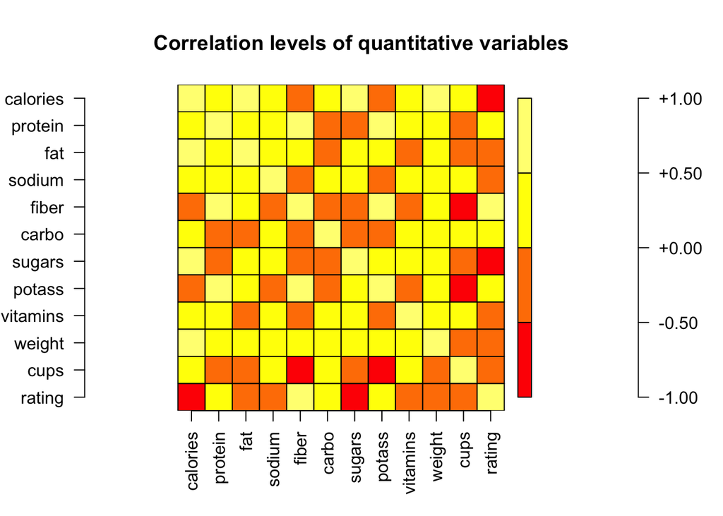

```r
par(mar=c(5.1, 4.1, 4.1, 4.1)) # modifying margins for matrix plot

# plotting matrix plot
plot(QuantCor, asp = 1, las = 2, xlab = "", ylab = "", main = "Correlation levels of quantitative variables")
```

We can now see that the highest positive correlation levels are in light yellow, while the highest negative correlation levels are in red. Excluding the diagonal of the matrix, we get:

- Strong positive correlations between:
  - calories and fat (0.507)
  - calories and sugars (0.569)
  - calories and weight (0.696)
  - protein and fiber (0.514)
  - protein and potassium (0.579)
  - fiber and potassium (0.912)
  - fiber and rating (0.603)
- Strong negative correlations between:
  - calories and rating (-0.694)
  - sugars and rating (-0.756)
  - fiber and cups (-0.514)
  - potassium and cups (-0.502)

## 6.1 Which pair of variables is most strongly correlated?

The strongest correlated pair is fiber and potassium with a factor of 0.912.

## 6.2 How can we reduce the number of variables based on these correlations?

Fiber, protein and potassium seem to form a triangle, they are all correlated. My assumption is that fibers typically contain high levels of potassium and proteins. We could thus keep fibers and get rid of potassium and proteins.

## 6.3 How would the correlations change if we normalized the data first?

We use the `scale()` function to scale each column of `CerealsQuantitative`. This will set the mean to 0 and the standard deviation to 1.

We will display the new correlation table and plot the correlation heatmap.

```r
CerealsQuantScaled <- scale(CerealsQuantitative)

QuantCorScaled = cor(x = CerealsQuantScaled, use = "complete.obs") # computing correlation matrix and omitting NA values from calculations (with complete.obs)

# displaying the resulting matrix as a table
kable_styling(kable(round(QuantCorScaled,3)), full_width = TRUE)
```

|  | calories | protein | fat | sodium | fiber | carbo | sugars | potass | vitamins | weight | cups | rating |
| --- | --- | --- | --- | --- | --- | --- | --- | --- | --- | --- | --- | --- |
| calories | 1.000 | 0.034 | 0.507 | 0.296 | -0.295 | 0.271 | 0.569 | -0.071 | 0.260 | 0.696 | 0.089 | -0.694 |
| protein | 0.034 | 1.000 | 0.202 | 0.012 | 0.514 | -0.037 | -0.287 | 0.579 | 0.055 | 0.231 | -0.242 | 0.467 |
| fat | 0.507 | 0.202 | 1.000 | 0.001 | 0.014 | -0.285 | 0.287 | 0.200 | -0.031 | 0.222 | -0.158 | -0.405 |
| sodium | 0.296 | 0.012 | 0.001 | 1.000 | -0.071 | 0.328 | 0.037 | -0.039 | 0.332 | 0.313 | 0.120 | -0.383 |
| fiber | -0.295 | 0.514 | 0.014 | -0.071 | 1.000 | -0.379 | -0.151 | 0.912 | -0.039 | 0.246 | -0.514 | 0.603 |
| carbo | 0.271 | -0.037 | -0.285 | 0.328 | -0.379 | 1.000 | -0.452 | -0.365 | 0.254 | 0.145 | 0.358 | 0.056 |
| sugars | 0.569 | -0.287 | 0.287 | 0.037 | -0.151 | -0.452 | 1.000 | 0.001 | 0.073 | 0.461 | -0.032 | -0.756 |
| potass | -0.071 | 0.579 | 0.200 | -0.039 | 0.912 | -0.365 | 0.001 | 1.000 | -0.003 | 0.421 | -0.502 | 0.416 |
| vitamins | 0.260 | 0.055 | -0.031 | 0.332 | -0.039 | 0.254 | 0.073 | -0.003 | 1.000 | 0.320 | 0.134 | -0.214 |
| weight | 0.696 | 0.231 | 0.222 | 0.313 | 0.246 | 0.145 | 0.461 | 0.421 | 0.320 | 1.000 | -0.202 | -0.300 |
| cups | 0.089 | -0.242 | -0.158 | 0.120 | -0.514 | 0.358 | -0.032 | -0.502 | 0.134 | -0.202 | 1.000 | -0.223 |
| rating | -0.694 | 0.467 | -0.405 | -0.383 | 0.603 | 0.056 | -0.756 | 0.416 | -0.214 | -0.300 | -0.223 | 1.000 |

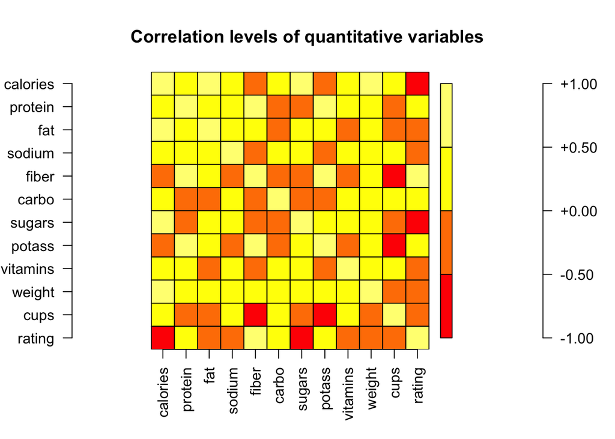

```r
par(mar=c(5.1, 4.1, 4.1, 4.1)) # modifying margins for matrix plot

# plotting matrix plot
plot(QuantCorScaled, asp = 1, las = 2, xlab = "", ylab = "", main = "Correlation levels of quantitative variables", scaled)
```

We can see that scaling the variables hasn’t changed the correlations.